# Car Price Prediction Using Random Forest Regressor

#### Requirements

The model should be able to predict the price of a used car. It should generalize to new data, meaning it should predict the price of a used car that it has not seen before.

#### Deliverables

The project should be completed in two parts:

1. Each student is required to submit a Jupyter Notebook that contains all the code used for the project, along with an exported HTML document to Moodle.
2. A prediction file should be submitted to the Kaggle competition. (You can submit your predictions 5 times a day before the deadline, and a small proportion of the submission is used for a real-time leaderboard.)

#### Grading

The assignment will be graded based on the following criteria:

- The accuracy of the model
- The ability of the model to generalize to new data
- The clarity of the documentation for the model

The owners of the best 3 models will receive a bonus to their overall course grade: 5%, 2%, and 1% based on their position.

#### Timeline

The competition closes on April 8. Late submissions are not accepted.

#### Data Description

- **Price**: Dependent variable
- **Year**: Year the car was produced
- **Mileage**: Kilometers driven by the car
- **City**: City where the car was sold
- **State**: State where the car was sold
- **Id**: A unique identifier for the used car
- **Make**: Manufacturer of the car
- **Model**: The model (name) of the car

#### Evaluation

The performance of the submission is measured using **Mean Squared Error (MSE)**.

#### Prediction file

Should be CSV with ID column and predicted price column

```python
import numpy as np
import pandas as pd
import seaborn as sns
import matplotlib.pyplot as plt

from sklearn.linear_model import LinearRegression, Ridge
from sklearn.ensemble import RandomForestRegressor
from sklearn.model_selection import train_test_split, cross_val_score, GridSearchCV
from statsmodels.stats.outliers_influence import variance_inflation_factor
from sklearn.preprocessing import MinMaxScaler

from sklearn.metrics import classification_report, accuracy_score, f1_score, recall_score, precision_score, confusion_matrix, roc_curve, roc_auc_score, make_scorer
from sklearn.metrics import mean_squared_error
from sklearn.metrics import r2_score
```

## Get data

```python
df = pd.read_csv("used_car_train.csv")
df= df.drop('id', axis='columns')

df.head()
```

|  | Price | Year | Mileage | City | State | Make | Model |
| --- | --- | --- | --- | --- | --- | --- | --- |
| 0 | 41285 | 2017 | 13336 | El Cajon | CA | BMW | X3sDrive28i |
| 1 | 8986 | 2009 | 56652 | Southborogh | MA | Toyota | Corolla4dr |
| 2 | 17477 | 2017 | 21265 | Fort Worth | TX | Kia | OptimaLX |
| 3 | 27000 | 2017 | 5180 | Modesto | CA | Nissan | 370ZCoupe |
| 4 | 27888 | 2014 | 46885 | Lauderdale Lakes | FL | BMW | 5 |

```python
df['Price'].mean()
```

```
np.float64(21463.812309411765)
```

```python
row_count = df.shape[0]
print("Total number of rows:", row_count)
```

```
Total number of rows: 850000
```

## Data preprocessing

### Check for null values

```python
# Checking for missing values using isnull()
print("Check for null values")
print("sum of null values: ", df.isnull().sum())

if df.isnull().sum().sum() == 0:
    print(f"\nThere are no null values: {df.isnull().sum().sum()}")
```

```
Check for null values
sum of null values:  Price      0
Year       0
Mileage    0
City       0
State      0
Make       0
Model      0
dtype: int64

There are no null values: 0
```

```python
df.info()
```

```
<class 'pandas.core.frame.DataFrame'>
RangeIndex: 850000 entries, 0 to 849999
Data columns (total 7 columns):
 #   Column   Non-Null Count   Dtype
---  ------   --------------   -----
 0   Price    850000 non-null  int64
 1   Year     850000 non-null  int64
 2   Mileage  850000 non-null  int64
 3   City     850000 non-null  object
 4   State    850000 non-null  object
 5   Make     850000 non-null  object
 6   Model    850000 non-null  object
dtypes: int64(3), object(4)
memory usage: 45.4+ MB
```

### Remove duplicate rows where every single column is the same including price

```python
df.duplicated().sum()
```

```
np.int64(552)
```

```python
df = df.drop_duplicates() #remove rows which are exact duplicates in every column
```

```python
df.duplicated().sum()
```

```
np.int64(0)
```

### Inspect unique categorical values

```python
print(df['Make'].unique())
print(df['Model'].unique())
print(df['City'].unique())
print(df['State'].unique())
```

```
['BMW' 'Toyota' 'Kia' 'Nissan' 'Hyundai' 'Land' 'Subaru' 'Honda'
 'Volkswagen' 'Chevrolet' 'Ford' 'Mercedes-Benz' 'MINI' 'Dodge' 'Ram'
 'GMC' 'Jeep' 'Buick' 'Audi' 'Cadillac' 'Acura' 'INFINITI' 'Mazda'
 'Ferrari' 'Scion' 'Volvo' 'Lexus' 'Lincoln' 'HUMMER' 'Jaguar' 'Chrysler'
 'Porsche' 'FIAT' 'Mitsubishi' 'Oldsmobile' 'Aston' 'Mercury' 'Pontiac'
 'Saab' 'Maserati' 'Suzuki' 'Saturn' 'smart' 'Tesla' 'Lamborghini' 'Lotus'
 'Bentley' 'Genesis' 'Rolls-Royce' 'Plymouth' 'Isuzu' 'Fisker' 'Alfa'
 'McLaren' 'AM' 'Maybach' 'Freightliner' 'Geo']
['X3sDrive28i' 'Corolla4dr' 'OptimaLX' ... 'M6M6' 'Previa3dr' 'Equinox4d']
['El Cajon' 'Southborogh' 'Fort Worth' ... 'AVON' 'Royston' 'Pen Argyl']
[' CA' ' MA' ' TX' ' FL' ' GA' ' LA' ' AR' ' AL' ' DE' ' SC' ' NJ' ' UT'
 ' MI' ' MN' ' WI' ' AZ' ' NC' ' IA' ' TN' ' KY' ' VA' ' PA' ' MD' ' OK'
 ' WA' ' MO' ' IN' ' OH' ' CO' ' SD' ' IL' ' KS' ' NY' ' OR' ' NV' ' MT'
 ' NH' ' CT' ' ID' ' NM' ' NE' ' WV' ' AK' ' MS' ' RI' ' ME' ' HI' ' VT'
 ' WY' ' ND' ' Fl' ' Va' ' Ga' ' Md' ' ga' ' Az' ' DC' ' Ca' ' Oh']
```

#### Fix case inconsistencies in State

```python
print("\nUnique states before being all lowercase")
print(df['State'].value_counts().shape[0])
df['State'] = df['State'].str.upper() #there are some lowercase duplicates of states, to prevent the model from treating them as separate categories i need to put all of them in caps
print("After:")
df['State'].unique().shape
```

```
Unique states before being all lowercase
59
After:
```

```
(51,)
```

#### Fix case inconsistencies in City

```python
print("\nCity")
print("Before converting all to lowercase: ")
print(df['City'].value_counts().shape[0])
print(df['City'].unique().shape)

# Trim leading/trailing whitespace
df['City'] = df['City'].str.strip()

# Convert all city names to lowercase
df['City'] = df['City'].str.lower()

print("After converting all to lowercase: ")
print(df['City'].value_counts().shape[0])
print(df['City'].unique().shape)
```

```
City
Before converting all to lowercase:
2553
(2553,)
After converting all to lowercase:
2408
(2408,)
```

#### Fix case inconsistencies in Model

```python
print("\nModel")
print("Before converting all to lowercase: ")
print(df['Model'].value_counts().shape[0])
print(df['Model'].unique().shape)

# Trim leading/trailing whitespace
df['Model'] = df['Model'].str.strip()

# Convert all city names to lowercase
df['Model'] = df['Model'].str.lower()

print("After converting all to lowercase: ")
print(df['Model'].value_counts().shape[0])
print(df['Model'].unique().shape)
```

```
Model
Before converting all to lowercase:
2734
(2734,)
After converting all to lowercase:
2697
(2697,)
```

### View Statistics

```python
df.describe().map(lambda x: f"{x:,.2f}") #making it more readable
```

|  | Price | Year | Mileage |
| --- | --- | --- | --- |
| count | 849,448.00 | 849,448.00 | 849,448.00 |
| mean | 21,458.44 | 2,013.29 | 52,539.22 |
| std | 13,594.70 | 3.42 | 41,986.73 |
| min | 1,500.00 | 1,997.00 | 5.00 |
| 25% | 13,000.00 | 2,012.00 | 23,864.00 |
| 50% | 18,500.00 | 2,014.00 | 40,279.00 |
| 75% | 26,995.00 | 2,016.00 | 72,220.00 |
| max | 499,500.00 | 2,018.00 | 2,856,196.00 |

### Visualize

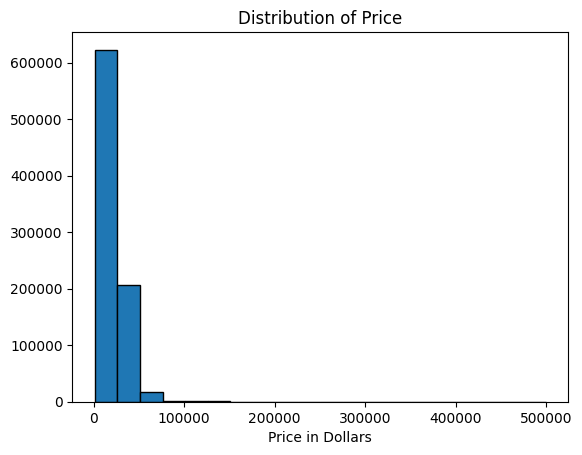

```
Maximum price value: 499500
Minimum price value: 1500
```

```python
plt.hist(df['Price'], bins=20, edgecolor="black")
plt.title("Distribution of Price")
plt.xlabel("Price in Dollars")
plt.show()

max_value = df["Price"].max()
min_value = df["Price"].min()

print("Maximum price value:", max_value)
print("Minimum price value:", min_value)
```

Distribution is highly skewed to cheaper cars

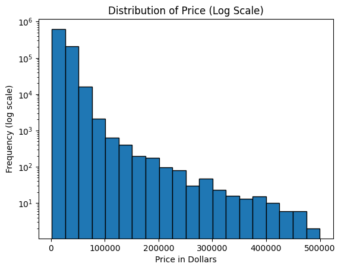

```python
# Plot histogram with log scale so that it is easier to compare small and large values
plt.hist(df['Price'], bins=20, edgecolor="black")
plt.yscale("log")  # Apply log scale to Y-axis
plt.title("Distribution of Price (Log Scale)")
plt.xlabel("Price in Dollars")
plt.ylabel("Frequency (log scale)")
plt.show()
```

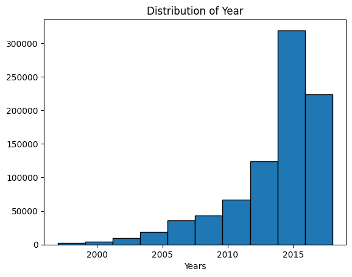

```
Maximum year value: 2018
Minimum year value: 1997
```

```python
plt.hist(df['Year'], bins=10, edgecolor="black")
plt.title("Distribution of Year")
plt.xlabel("Years")
plt.show()

max_value = df["Year"].max()
min_value = df["Year"].min()

print("Maximum year value:", max_value)
print("Minimum year value:", min_value)
```

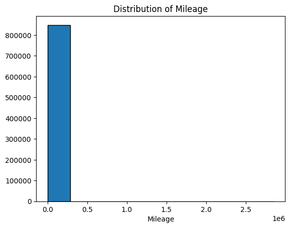

```
Maximum mileage value: 2856196
Minimum mileage value: 5
```

```python
plt.hist(df['Mileage'], bins=10, edgecolor="black")
plt.title("Distribution of Mileage")
plt.xlabel("Mileage")
plt.show()

max_value = df["Mileage"].max()
min_value = df["Mileage"].min()

print("Maximum mileage value:", max_value)
print("Minimum mileage value:", min_value)
```

Mileage is also super skewed to lower numbers

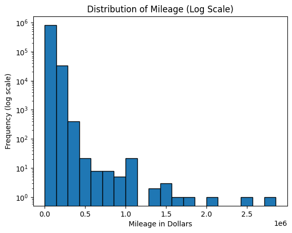

```python
# Plot histogram with log scale so that it is easier to compare small and large values
plt.hist(df['Mileage'], bins=20, edgecolor="black")
plt.yscale("log")  # Apply log scale to Y-axis
plt.title("Distribution of Mileage (Log Scale)")
plt.xlabel("Mileage in Dollars")
plt.ylabel("Frequency (log scale)")
plt.show()
```

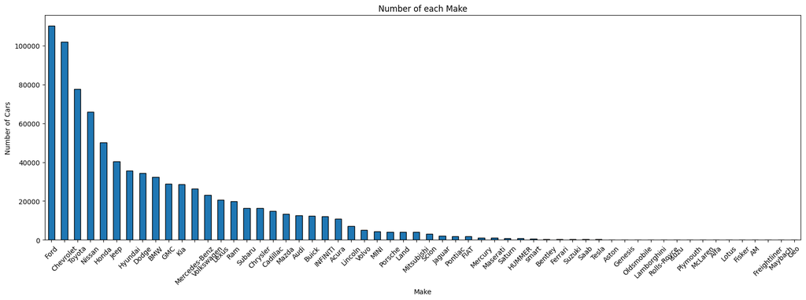

```python
# Count occurrences of each city
make_counts = df['Make'].value_counts()

# Create a bar chart
plt.figure(figsize=(20, 6))  # Adjust size for readability
make_counts.plot(kind='bar', edgecolor="black")

# Formatting
plt.title("Number of each Make")
plt.xlabel("Make")
plt.ylabel("Number of Cars")
plt.xticks(rotation=45)  # Rotate labels to prevent overlap
plt.show()
```

The makes are pretty imabalanced

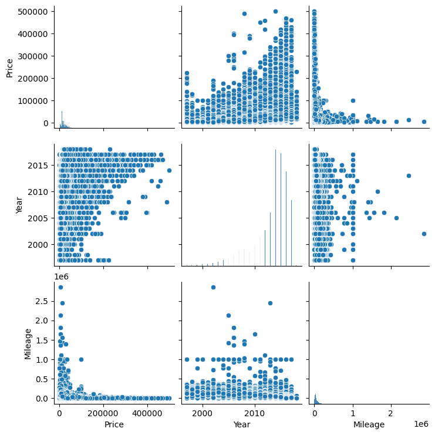

```python
# correlation analysis

sns.pairplot(df)
plt.show()
```

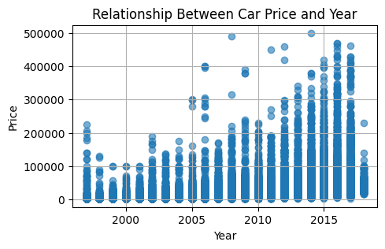

```python
plt.figure(figsize=(5, 3))
plt.scatter(df['Year'], df['Price'], alpha=0.6)
plt.title('Relationship Between Car Price and Year')
plt.xlabel('Year')
plt.ylabel('Price')
plt.grid(True)
plt.show()
```

```python
#checking for multicollinearity of the numeric attributes
def calc_vif(X):
    vif = pd.DataFrame()
    vif["variables"] = X.columns
    vif["VIF"] = [variance_inflation_factor(X.values, i) for i in range (X.shape[1])]

    return (vif)

    #VIF starts at 1 and has no upper limit
    #VIF = 1, no correlation between the independent variable and the other variables
    #VIF exceeding 5 or 10 indicates high multicollinearity between this independent variable and the others


print(calc_vif(df[['Mileage', 'Year']]))

print(calc_vif(df[['Mileage', 'Year', 'Price']]))

print(calc_vif(df[['Mileage', 'Price']]))

print(calc_vif(df[['Year', 'Price']]))

#price has high multicollinearity when it is with both mileage and year, but since
#it wont be part of training this is fine
```

```
  variables       VIF
0   Mileage  2.557518
1      Year  2.557518
  variables       VIF
0   Mileage  3.104039
1      Year  7.932768
2     Price  4.246672
  variables       VIF
0   Mileage  1.369124
1     Price  1.369124
  variables       VIF
0      Year  3.498971
1     Price  3.498971
```

## Feature engineering

### Add Almost_New binary column for very low mileage cars (ends up getting removed)

```python
df['Almost_New'] = (df['Mileage'] < 100).astype(int)

almost_new_cars = df[df['Almost_New'] == 1]
print(almost_new_cars)
```

```
        Price  Year  Mileage               City State      Make         Model  \
17      36299  2015       66        los angeles    CA      Ford       edgesel
252     16999  2017       77         jenkintown    PA    Nissan         nv200
648     12498  2016        9        playa vista    CA    Nissan         versa
717     24616  2018       85          mascoutah    IL      Jeep  compasssport
839     17025  2014       19  arlington heights    IL    Nissan      sentrasr
...       ...   ...      ...                ...   ...       ...           ...
848649  52200  2017       30       white plains    NY  INFINITI        q50red
848953  16955  2017        5        new orleans    LA     Dodge    journeysxt
849007  38987  2017       15          las vegas    NV   Hyundai         santa
849362  39995  2016       29           new york    NY     Volvo         s60t6
849713  38498  2016       56        playa vista    CA     Acura       rlxwith

        Almost_New
17               1
252              1
648              1
717              1
839              1
...            ...
848649           1
848953           1
849007           1
849362           1
849713           1

[4096 rows x 8 columns]
```

### Add a column for the current year

```python
from datetime import datetime

# Get the current year dynamically
current_year = datetime.now().year

df['Current_Year'] = current_year

df.head()
```

|  | Price | Year | Mileage | City | State | Make | Model | Almost_New | Current_Year |
| --- | --- | --- | --- | --- | --- | --- | --- | --- | --- |
| 0 | 41285 | 2017 | 13336 | el cajon | CA | BMW | x3sdrive28i | 0 | 2025 |
| 1 | 8986 | 2009 | 56652 | southborogh | MA | Toyota | corolla4dr | 0 | 2025 |
| 2 | 17477 | 2017 | 21265 | fort worth | TX | Kia | optimalx | 0 | 2025 |
| 3 | 27000 | 2017 | 5180 | modesto | CA | Nissan | 370zcoupe | 0 | 2025 |
| 4 | 27888 | 2014 | 46885 | lauderdale lakes | FL | BMW | 5 | 0 | 2025 |

#### Check correlation of categorical columns before encoding

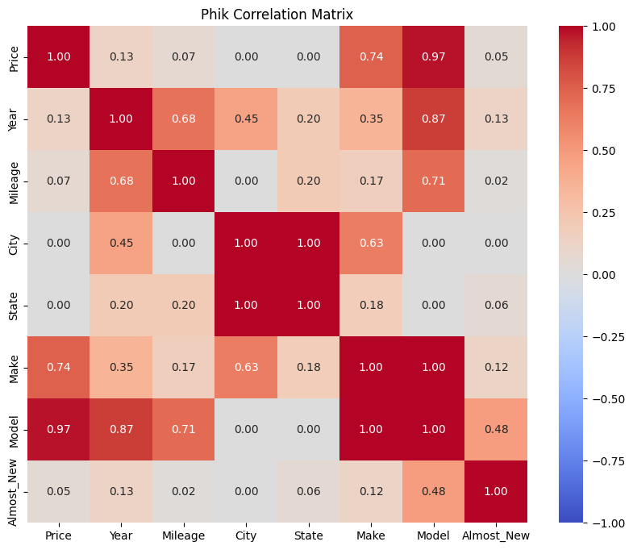

```
               Price      Year   Mileage      City     State      Make  \
Price       1.000000  0.132509  0.065446  0.000000  0.000000  0.743393
Year        0.132509  1.000000  0.676425  0.451560  0.196630  0.352968
Mileage     0.065446  0.676425  1.000000  0.000000  0.201337  0.170106
City        0.000000  0.451560  0.000000  1.000000  0.999691  0.625032
State       0.000000  0.196630  0.201337  0.999691  1.000000  0.180646
Make        0.743393  0.352968  0.170106  0.625032  0.180646  1.000000
Model       0.969331  0.873464  0.707689  0.000000  0.000000  0.999955
Almost_New  0.047806  0.126788  0.016079  0.000000  0.056688  0.121860

               Model  Almost_New
Price       0.969331    0.047806
Year        0.873464    0.126788
Mileage     0.707689    0.016079
City        0.000000    0.000000
State       0.000000    0.056688
Make        0.999955    0.121860
Model       1.000000    0.479062
Almost_New  0.479062    1.000000
```

```python
import phik
copy_df = df.sample(10000)

copy_df['City'] = copy_df['City'].astype('category')
copy_df['Model'] = copy_df['Model'].astype('category')
copy_df['Make'] = copy_df['Make'].astype('category')
copy_df['State'] = copy_df['State'].astype('category')
interval_cols = ['Price', 'Year', 'Mileage', 'Current_Year', 'Almost_New']
phik_matrix = copy_df.phik_matrix(interval_cols=interval_cols)

plt.figure(figsize=(10, 8))
sns.heatmap(phik_matrix, annot=True, cmap='coolwarm', fmt='.2f', vmin=-1, vmax=1)
plt.title('Phik Correlation Matrix')
plt.show()

print(phik_matrix)
```

#### Dropping weakly correlated features or features which cause multicollinearity

```python
df = df.drop(columns=['Almost_New', 'State'])
df.head()
```

|  | Price | Year | Mileage | City | Make | Model | Current_Year |
| --- | --- | --- | --- | --- | --- | --- | --- |
| 0 | 41285 | 2017 | 13336 | el cajon | BMW | x3sdrive28i | 2025 |
| 1 | 8986 | 2009 | 56652 | southborogh | Toyota | corolla4dr | 2025 |
| 2 | 17477 | 2017 | 21265 | fort worth | Kia | optimalx | 2025 |
| 3 | 27000 | 2017 | 5180 | modesto | Nissan | 370zcoupe | 2025 |
| 4 | 27888 | 2014 | 46885 | lauderdale lakes | BMW | 5 | 2025 |

#### Seeing if an Age column has higher correlation than year

```python
df_age = df

df_age['Age'] = df_age['Current_Year'] - df_age['Year']

df_age = df_age.drop(columns=['Current_Year', 'Year'])

df_age.head()
```

|  | Price | Mileage | City | Make | Model | Age |
| --- | --- | --- | --- | --- | --- | --- |
| 0 | 41285 | 13336 | el cajon | BMW | x3sdrive28i | 8 |
| 1 | 8986 | 56652 | southborogh | Toyota | corolla4dr | 16 |
| 2 | 17477 | 21265 | fort worth | Kia | optimalx | 8 |
| 3 | 27000 | 5180 | modesto | Nissan | 370zcoupe | 8 |
| 4 | 27888 | 46885 | lauderdale lakes | BMW | 5 | 11 |

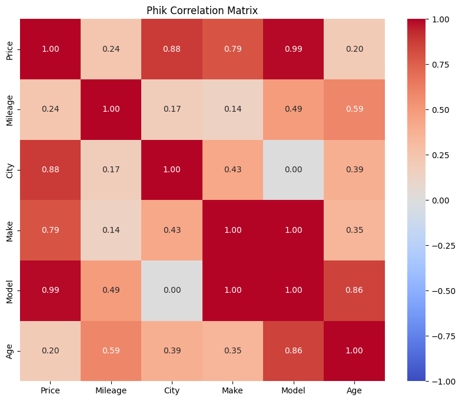

```
            Price   Mileage      City      Make     Model       Age
Price    1.000000  0.235002  0.876829  0.789304  0.987971  0.202912
Mileage  0.235002  1.000000  0.173403  0.141196  0.489570  0.593121
City     0.876829  0.173403  1.000000  0.427551  0.000000  0.389869
Make     0.789304  0.141196  0.427551  1.000000  0.999977  0.350150
Model    0.987971  0.489570  0.000000  0.999977  1.000000  0.859053
Age      0.202912  0.593121  0.389869  0.350150  0.859053  1.000000
```

```python
copy_df = df_age.sample(10000)

copy_df['City'] = copy_df['City'].astype('category')
copy_df['Model'] = copy_df['Model'].astype('category')
copy_df['Make'] = copy_df['Make'].astype('category')
interval_cols = ['Price', 'Mileage', 'Age']
phik_matrix = copy_df.phik_matrix(interval_cols=interval_cols)

plt.figure(figsize=(10, 8))
sns.heatmap(phik_matrix, annot=True, cmap='coolwarm', fmt='.2f', vmin=-1, vmax=1)
plt.title('Phik Correlation Matrix')
plt.show()

print(phik_matrix)
```

Age does have a higher correlation with price than year. Dropping state gave city a higher correlation with price.

#### Adding Age to actual df

```python
df['Age'] = df['Current_Year'] - df['Year']

df = df.drop(columns=['Current_Year', 'Year'])

df.head()
```

|  | Price | Mileage | City | Make | Model | Age |
| --- | --- | --- | --- | --- | --- | --- |
| 0 | 41285 | 13336 | el cajon | BMW | x3sdrive28i | 8 |
| 1 | 8986 | 56652 | southborogh | Toyota | corolla4dr | 16 |
| 2 | 17477 | 21265 | fort worth | Kia | optimalx | 8 |
| 3 | 27000 | 5180 | modesto | Nissan | 370zcoupe | 8 |
| 4 | 27888 | 46885 | lauderdale lakes | BMW | 5 | 11 |

#### See if log mileage has better correlation with price

```python
df_lm = df
df_lm['Log_Mileage'] = np.log1p(df_lm['Mileage'])
df_lm = df_lm.drop(columns=['Mileage'])
df_lm.head()
```

|  | Price | City | Make | Model | Age | Log_Mileage |
| --- | --- | --- | --- | --- | --- | --- |
| 0 | 41285 | el cajon | BMW | x3sdrive28i | 8 | 9.498297 |
| 1 | 8986 | southborogh | Toyota | corolla4dr | 16 | 10.944700 |
| 2 | 17477 | fort worth | Kia | optimalx | 8 | 9.964865 |
| 3 | 27000 | modesto | Nissan | 370zcoupe | 8 | 8.552753 |
| 4 | 27888 | lauderdale lakes | BMW | 5 | 11 | 10.755474 |

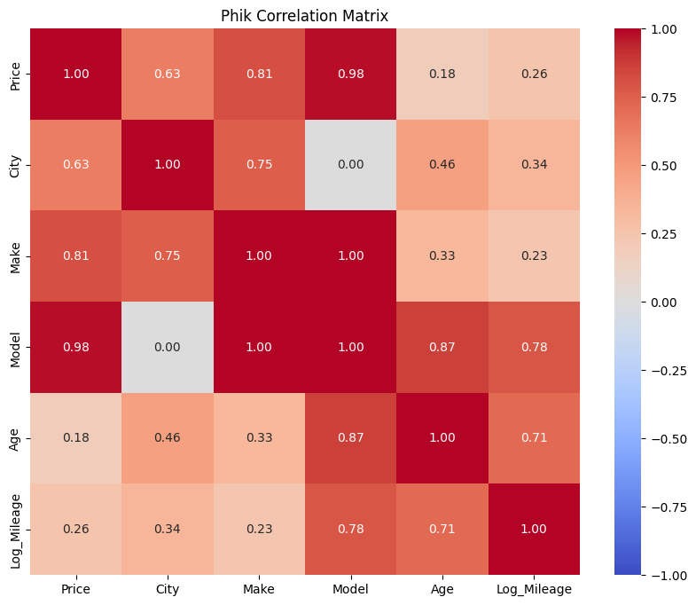

```
                Price      City      Make     Model       Age  Log_Mileage
Price        1.000000  0.632030  0.806299  0.979669  0.175675     0.255479
City         0.632030  1.000000  0.750665  0.000000  0.462567     0.344053
Make         0.806299  0.750665  1.000000  0.999976  0.334882     0.234648
Model        0.979669  0.000000  0.999976  1.000000  0.865288     0.782383
Age          0.175675  0.462567  0.334882  0.865288  1.000000     0.712178
Log_Mileage  0.255479  0.344053  0.234648  0.782383  0.712178     1.000000
```

```python
copy_df = df_lm.sample(10000)

copy_df['City'] = copy_df['City'].astype('category')
copy_df['Model'] = copy_df['Model'].astype('category')
copy_df['Make'] = copy_df['Make'].astype('category')
interval_cols = ['Price', 'Log_Mileage', 'Age']
phik_matrix = copy_df.phik_matrix(interval_cols=interval_cols)

plt.figure(figsize=(10, 8))
sns.heatmap(phik_matrix, annot=True, cmap='coolwarm', fmt='.2f', vmin=-1, vmax=1)
plt.title('Phik Correlation Matrix')
plt.show()

print(phik_matrix)
```

**Very subtle difference in correlation for log mileage and regular mileage. I should test performance between the two to see the true impact.**

#### Saving the two versions of the df for future use

```python
df_lm.to_csv('lm_age_noState.csv', index=False) #saving with log mileage
```

```python
df.to_csv('age_noState.csv', index=False) #saving with regular mileage
```

### Encode categorical data using target encoding with mean price for category

#### Encode the Make

This is categorical data, which needs to be encoded as numerical. Assigning a unique number to each make would not make sense, since the model may begin to recognize trends that are not really there (such as 5 being greater than 4, but no make is greater than another in that way).

There are a lot of unique makes, so one hot encoding is not a good approach as it would create too many new features.

Target encoding would encode each one based on the mean price of the category. Frequency encoding would encode each one based on the frequency of the category.

I am going to do Target encoding because the goal is to predict price.

```python
#encode the make
# Target Encoding for Make
make_mean_price = df.groupby('Make')['Price'].mean()
df['Make_mean_price'] = df['Make'].map(make_mean_price)

df.drop(columns=['Make'], inplace=True)
```

```python
#encode the model
# Target Encoding for Model
model_mean_price = df.groupby('Model')['Price'].mean()
df['Model_mean_price'] = df['Model'].map(model_mean_price)

df.drop(columns=['Model'], inplace=True)
```

```python
#encode the city

# Target Encoding for City
city_mean_price = df.groupby('City')['Price'].mean()
df['City_mean_price'] = df['City'].map(city_mean_price)

# Drop original column
df.drop(columns=['City'], inplace=True)
```

```python
df = df.drop(columns=['Log_Mileage'])
df.head()
```

|  | Price | Mileage | Age | Make_mean_price | Model_mean_price | City_mean_price |
| --- | --- | --- | --- | --- | --- | --- |
| 0 | 41285 | 13336 | 8 | 26915.311831 | 37888.050761 | 19268.381828 |
| 1 | 8986 | 56652 | 16 | 19604.611882 | 7928.810063 | 18921.897436 |
| 2 | 17477 | 21265 | 8 | 15580.346728 | 14848.553860 | 23406.965504 |
| 3 | 27000 | 5180 | 8 | 16725.668652 | 25801.583190 | 21725.388017 |
| 4 | 27888 | 46885 | 11 | 26915.311831 | 25978.924259 | 19116.834764 |

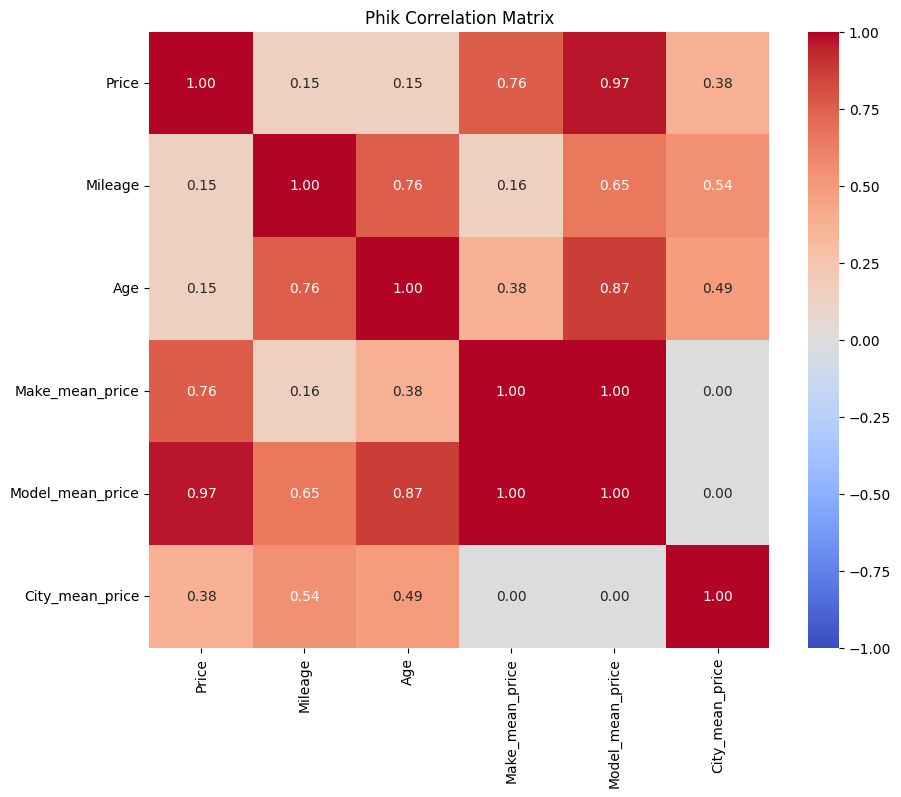

```
                     Price   Mileage       Age  Make_mean_price  \
Price             1.000000  0.150345  0.154442         0.760003
Mileage           0.150345  1.000000  0.755265         0.161817
Age               0.154442  0.755265  1.000000         0.382304
Make_mean_price   0.760003  0.161817  0.382304         1.000000
Model_mean_price  0.967284  0.652815  0.868574         0.999987
City_mean_price   0.376629  0.539513  0.485832         0.000000

                  Model_mean_price  City_mean_price
Price                     0.967284         0.376629
Mileage                   0.652815         0.539513
Age                       0.868574         0.485832
Make_mean_price           0.999987         0.000000
Model_mean_price          1.000000         0.000000
City_mean_price           0.000000         1.000000
```

```python
copy_df = df.sample(10000)

interval_cols = ['Price', 'Mileage', 'Age', 'City', 'Model', 'Make']
phik_matrix = copy_df.phik_matrix(interval_cols=interval_cols)

plt.figure(figsize=(10, 8))
sns.heatmap(phik_matrix, annot=True, cmap='coolwarm', fmt='.2f', vmin=-1, vmax=1)
plt.title('Phik Correlation Matrix')
plt.show()

print(phik_matrix)
```

```python
#save the target encoded data with mileage
df.to_csv('target_encoded_age_noState.csv', index=False) #saving with regular mileage
```

```python
#do the same for the data with log mileage

#encode the make
# Target Encoding for Make
make_mean_price = df_lm.groupby('Make')['Price'].mean()
df_lm['Make_mean_price'] = df_lm['Make'].map(make_mean_price)

df_lm.drop(columns=['Make'], inplace=True)

#encode the model
# Target Encoding for Model
model_mean_price = df_lm.groupby('Model')['Price'].mean()
df_lm['Model_mean_price'] = df_lm['Model'].map(model_mean_price)

df_lm.drop(columns=['Model'], inplace=True)

#encode the city
# Target Encoding for City
city_mean_price = df_lm.groupby('City')['Price'].mean()
df_lm['City_mean_price'] = df_lm['City'].map(city_mean_price)

# Drop original column
df_lm.drop(columns=['City'], inplace=True)

df_lm.head()
```

|  | Price | Age | Log_Mileage | Make_mean_price | Model_mean_price | City_mean_price |
| --- | --- | --- | --- | --- | --- | --- |
| 0 | 41285 | 8 | 9.498297 | 26915.311831 | 37888.050761 | 19268.381828 |
| 1 | 8986 | 16 | 10.944700 | 19604.611882 | 7928.810063 | 18921.897436 |
| 2 | 17477 | 8 | 9.964865 | 15580.346728 | 14848.553860 | 23406.965504 |
| 3 | 27000 | 8 | 8.552753 | 16725.668652 | 25801.583190 | 21725.388017 |
| 4 | 27888 | 11 | 10.755474 | 26915.311831 | 25978.924259 | 19116.834764 |

```python
df.to_csv('target_encoded_lm_age_noState.csv', index=False) #saving with log mileage
```

### Trying frequency encoding too (ends up being not good)

```python
#using only the data with regular mileage because i already determined log mileage does not help

#reload non-encoded data from csv

df_freq = pd.read_csv('age_noState.csv')
df_freq.drop(columns=['Log_Mileage'], inplace=True)
df_freq.head()
```

|  | Price | Mileage | City | Make | Model | Age |
| --- | --- | --- | --- | --- | --- | --- |
| 0 | 41285 | 13336 | el cajon | BMW | x3sdrive28i | 8 |
| 1 | 8986 | 56652 | southborogh | Toyota | corolla4dr | 16 |
| 2 | 17477 | 21265 | fort worth | Kia | optimalx | 8 |
| 3 | 27000 | 5180 | modesto | Nissan | 370zcoupe | 8 |
| 4 | 27888 | 46885 | lauderdale lakes | BMW | 5 | 11 |

```python
# Frequency encode the 'Make' column
make_frequency = df_freq['Make'].value_counts() / len(df_freq)  # Calculate the frequency of each category

# Map the frequencies to the 'Make' column in the dataframe
df_freq['Make_frequency'] = df_freq['Make'].map(make_frequency)

df_freq.drop(columns=['Make'], inplace=True)


# Frequency encode the 'Model' column
make_frequency = df_freq['Model'].value_counts() / len(df_freq)  # Calculate the frequency of each category

# Map the frequencies to the 'Model' column in the dataframe
df_freq['Model_frequency'] = df_freq['Model'].map(make_frequency)

df_freq.drop(columns=['Model'], inplace=True)


# Frequency encode the 'City' column
make_frequency = df_freq['City'].value_counts() / len(df_freq)  # Calculate the frequency of each category

# Map the frequencies to the 'City' column in the dataframe
df_freq['City_frequency'] = df_freq['City'].map(make_frequency)

df_freq.drop(columns=['City'], inplace=True)

df_freq.head()
```

|  | Price | Mileage | Age | Make_frequency | Model_frequency | City_frequency |
| --- | --- | --- | --- | --- | --- | --- |
| 0 | 41285 | 13336 | 8 | 0.038051 | 0.000464 | 0.002112 |
| 1 | 8986 | 56652 | 16 | 0.091311 | 0.002597 | 0.000046 |
| 2 | 17477 | 21265 | 8 | 0.033603 | 0.003934 | 0.003140 |
| 3 | 27000 | 5180 | 8 | 0.077662 | 0.000686 | 0.000825 |
| 4 | 27888 | 46885 | 11 | 0.038051 | 0.006279 | 0.000549 |

#### Making a data set which is just target encoded and nothing else to compare and see if feature engineering helped

```python
#I am also going to get some data which I only encode categorical variables and do nothing else with, in order to compare performance
df_og =  pd.read_csv("used_car_train.csv")
df_og = df_og.drop('id', axis='columns')
```

```python
#encode the make
# Target Encoding for Make
make_mean_price = df_og.groupby('Make')['Price'].mean()
df_og['Make_mean_price'] = df_og['Make'].map(make_mean_price)

df_og.drop(columns=['Make'], inplace=True)

#encode the model
# Target Encoding for Model
model_mean_price = df_og.groupby('Model')['Price'].mean()
df_og['Model_mean_price'] = df_og['Model'].map(model_mean_price)

df_og.drop(columns=['Model'], inplace=True)

#encode the city
# Target Encoding for City
city_mean_price = df_og.groupby('City')['Price'].mean()
df_og['City_mean_price'] = df_og['City'].map(city_mean_price)

# Drop original column
df_og.drop(columns=['City'], inplace=True)

#target encode the state
state_mean_price = df_og.groupby('State')['Price'].mean()
df_og['State_mean_price'] = df_og['State'].map(state_mean_price)

# Drop original column
df_og.drop(columns=['State'], inplace=True)
```

```python
df_og.head()
```

|  | Price | Year | Mileage | Make_mean_price | Model_mean_price | City_mean_price | State_mean_price |
| --- | --- | --- | --- | --- | --- | --- | --- |
| 0 | 41285 | 2017 | 13336 | 26919.335983 | 37903.457071 | 19268.381828 | 21618.587957 |
| 1 | 8986 | 2009 | 56652 | 19605.493923 | 7928.810063 | 18921.897436 | 21680.836687 |
| 2 | 17477 | 2017 | 21265 | 15585.079787 | 14863.065334 | 23402.063320 | 23752.616291 |
| 3 | 27000 | 2017 | 5180 | 16726.072521 | 25801.583190 | 21725.388017 | 21618.587957 |
| 4 | 27888 | 2014 | 46885 | 26919.335983 | 25978.924259 | 19116.834764 | 20990.653518 |

## Model selection

This problem is centered around predicting the continuous value of price, so it is a regression problem. I could use linear regression, a decision tree regressor which would be good for non-linearly separabled data, or I could use a random forest regressor to improve generalization.

This data set has non-linear relationships such as city and price, so simple linear regression is not the best choice. A decision tree regressor is prone to overfitting and has limited generalization to unseen data, so also likely not the best choice. A random forest regressor may be slower and less interpretable, but it reduces overfitting, has better generalization, and can handle noisy data better.

Ultimately, I would like to go with a **Random Forest Regressor**.

### Split data into train and test

```python
X = df.drop(columns=['Price'])
y = df['Price']

X_lm = df_lm.drop(columns=['Price'])
y_lm = df_lm['Price']

#target encoded, regular mileage
X_train, X_test, y_train, y_test = train_test_split(X, y, test_size=0.2)

#target encoded, log mileage
X_train_lm, X_test_lm, y_train_lm, y_test_lm = train_test_split(X_lm, y_lm, test_size=0.2)
```

```python
#frequency encoded

X_freq = df_freq.drop(columns=['Price'])
y_freq = df_freq['Price']

X_train_f, X_test_f, y_train_f, y_test_f = train_test_split(X_freq, y_freq, test_size=0.2)
```

```python
# only target encoded and no other feature engineering done
X_og = df_og.drop(columns=['Price'])
y_og = df_og['Price']

X_train_og, X_test_og, y_train_og, y_test_og = train_test_split(X_og, y_og, test_size=0.2)
```

### Baseline Models (no hyperparameter tuning done)

I am going to compare how a basic RFR performs on differently feature engineered data sets

```python
#target encoded, regular mileage
rf_model = RandomForestRegressor()
rf_model.fit(X_train, y_train)
```

```
RandomForestRegressor()
```

```python
yhat = rf_model.predict(X_test)
print(yhat)
```

```
[11702.86 37250.45 31511.66 ... 17492.59 14456.2  15166.73]
```

```python
#target encoded, log mileage
rf_model_lm = RandomForestRegressor()
rf_model_lm.fit(X_train_lm, y_train_lm)
```

```
RandomForestRegressor()
```

```python
yhat_lm = rf_model_lm.predict(X_test_lm)
print(yhat_lm)
```

```
[11901.92 49472.79 39403.21 ... 13987.09 30111.62 28929.3 ]
```

```python
#frequency encoded, regular mileage
rf_model_freq = RandomForestRegressor()
rf_model_freq.fit(X_train_f, y_train_f)
```

```
RandomForestRegressor()
```

```python
yhat_freq = rf_model_freq.predict(X_test_f)
```

```python
#target encoded, no further feature engineering
rf_model_og = RandomForestRegressor()
rf_model_og.fit(X_train_og, y_train_og)
```

```
RandomForestRegressor()
```

```python
yhat_og = rf_model_og.predict(X_test_og)
```

#### Plot predictions using regular mileage and target encoded

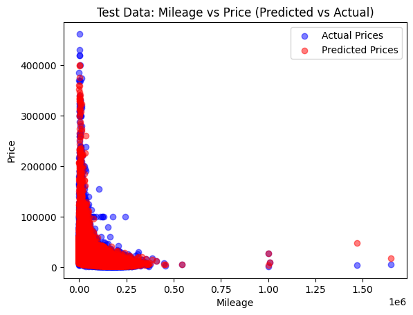

```python
# use the test data for plotting
plt.scatter(X_test['Mileage'], y_test, label="Actual Prices", alpha=0.5, color="blue")
plt.scatter(X_test['Mileage'], yhat, color="red", label="Predicted Prices", alpha=0.5)
plt.xlabel("Mileage")
plt.ylabel("Price")
plt.title("Test Data: Mileage vs Price (Predicted vs Actual)")
plt.legend()
plt.show()
```

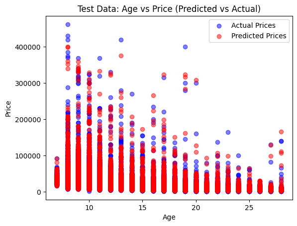

```python
plt.scatter(X_test['Age'], y_test, label="Actual Prices", alpha=0.5, color="blue")
plt.scatter(X_test['Age'], yhat, color="red", label="Predicted Prices", alpha=0.5)
plt.xlabel("Age")
plt.ylabel("Price")
plt.title("Test Data: Age vs Price (Predicted vs Actual)")
plt.legend()
plt.show()
```

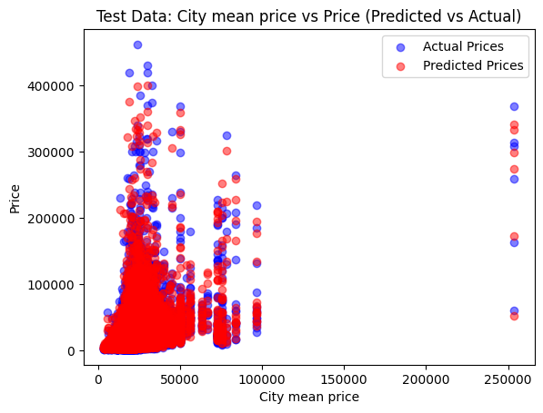

```python
plt.scatter(X_test['City_mean_price'], y_test, label="Actual Prices", alpha=0.5, color="blue")
plt.scatter(X_test['City_mean_price'], yhat, color="red", label="Predicted Prices", alpha=0.5)
plt.xlabel("City mean price")
plt.ylabel("Price")
plt.title("Test Data: City mean price vs Price (Predicted vs Actual)")
plt.legend()
plt.show()
```

##### Regular mileage and target encoding

```python
mse = mean_squared_error(y_test, yhat)
print(f"Mean Squared Error: {mse}")

rmse = np.sqrt(mse)

print(f"Root Mean Squared Error: {rmse}")

print(f"Average price of car: {df['Price'].mean()}")

print("\nSince the RMSE is ~4000 it means the baseline random tree regressor is often $4070 off from the actual value, since the average is ~20,000 that makes it off by about 19% of the average price. There is room for improvement.")
```

```
Mean Squared Error: 16753162.166580547
Root Mean Squared Error: 4093.062687839089
Average price of car: 21458.435742976617

Since the RMSE is ~4000 it means the baseline random tree regressor is often $4070 off from the actual value, since the average is ~20,000 that makes it off by about 19% of the average price. There is room for improvement.
```

```python
r2 = r2_score(y_test, yhat)
print(f"R-squared: {r2}")

#the closer to 1 the better, the closer to 0 the worse

print("Pretty dang good R squared score though!")
```

```
R-squared: 0.9087526384555946
Pretty dang good R squared score though!
```

##### Using log mileage and target encoding:

```python
mse = mean_squared_error(y_test_lm, yhat_lm)
print(f"Mean Squared Error: {mse}")

rmse = np.sqrt(mse)

print(f"Root Mean Squared Error: {rmse}")

print(f"Average price of car: {df['Price'].mean()}")

print("\nSince the RMSE is ~4000 it means the baseline random tree regressor is often $4070 off from the actual value, since the average is ~20,000 that makes it off by about 19% of the average price. There is room for improvement.")
```

```
Mean Squared Error: 16945857.85731678
Root Mean Squared Error: 4116.5346904060925
Average price of car: 21458.435742976617

Since the RMSE is ~4000 it means the baseline random tree regressor is often $4070 off from the actual value, since the average is ~20,000 that makes it off by about 19% of the average price. There is room for improvement.
```

```python
r2 = r2_score(y_test_lm, yhat_lm)
print(f"R-squared: {r2}")

#the closer to 1 the better, the closer to 0 the worse

print("Pretty dang good R squared score though!")
```

```
R-squared: 0.9076778770877549
Pretty dang good R squared score though!
```

**Result: Using log mileage is not an improvement**

##### Using frequency encoding and regular mileage:

```python
mse = mean_squared_error(y_test_f, yhat_freq)
print(f"Mean Squared Error: {mse}")

rmse = np.sqrt(mse)

print(f"Root Mean Squared Error: {rmse}")

print(f"Average price of car: {df['Price'].mean()}")

print("\nSince the RMSE is ~4000 it means the baseline random tree regressor is often $4070 off from the actual value, since the average is ~20,000 that makes it off by about 19% of the average price. There is room for improvement.")
```

```
Mean Squared Error: 19910139.784991834
Root Mean Squared Error: 4462.0779671574355
Average price of car: 21458.435742976617

Since the RMSE is ~4000 it means the baseline random tree regressor is often $4070 off from the actual value, since the average is ~20,000 that makes it off by about 19% of the average price. There is room for improvement.
```

```python
r2 = r2_score(y_test_f, yhat_freq)
print(f"R-squared: {r2}")

#the closer to 1 the better, the closer to 0 the worse
```

```
R-squared: 0.8870455433082182
```

**Results: Target encoding with regular mileage gives the best results of the feature engineered datasets.**

##### Using target encoding and no other feature engineering:

```python
mse = mean_squared_error(y_test_og, yhat_og)
print(f"Mean Squared Error: {mse}")

rmse = np.sqrt(mse)

print(f"Root Mean Squared Error: {rmse}")

print(f"Average price of car: {df_og['Price'].mean()}")

print("\nSince the RMSE is ~4000 it means the baseline random tree regressor is often $4070 off from the actual value, since the average is ~20,000 that makes it off by about 19% of the average price. There is room for improvement.")

r2 = r2_score(y_test_og, yhat_og)
print(f"R-squared: {r2}")

#the closer to 1 the better, the closer to 0 the worse
```

```
Mean Squared Error: 16041913.512666892
Root Mean Squared Error: 4005.2357624323304
Average price of car: 21463.812309411765

Since the RMSE is ~4000 it means the baseline random tree regressor is often $4070 off from the actual value, since the average is ~20,000 that makes it off by about 19% of the average price. There is room for improvement.
R-squared: 0.9121148948482191
```

**Result, the target encoded model with no further feature engineering had the best baseline performance.**

## Hyperparameter tuning

Going forward I will be using the target encoded data that has no further feature engineering

```python
#DISCLAIMER: this code is old and not used for the submission this file creates
max_depths = [4, 6, 8, 10]
n_estimators = [50, 100, 200]
for max_depth in max_depths:
    print("\n")
    print(f"RF Model with depth: {max_depth}")
    for n_estimator in n_estimators:
        rf = RandomForestRegressor(max_depth=max_depth, n_estimators=n_estimator, oob_score=True)
        rf.fit(X_train, y_train)
        print(f"\tNum estimators: {n_estimator}, OOB Score is: {rf.oob_score_}")
```

```
RF Model with depth: 4
	Num estimators: 50, OOB Score is: 0.7895802751796388
	Num estimators: 100, OOB Score is: 0.7848261458188036
	Num estimators: 200, OOB Score is: 0.7870136338680925


RF Model with depth: 6
	Num estimators: 50, OOB Score is: 0.8358800357583234
	Num estimators: 100, OOB Score is: 0.8365188431600812
	Num estimators: 200, OOB Score is: 0.8358700195210427


RF Model with depth: 8
	Num estimators: 50, OOB Score is: 0.8595500608952494
	Num estimators: 100, OOB Score is: 0.8604693762332599
	Num estimators: 200, OOB Score is: 0.8603208329068782


RF Model with depth: 10
	Num estimators: 50, OOB Score is: 0.8782820851358846
	Num estimators: 100, OOB Score is: 0.8783919407470006
	Num estimators: 200, OOB Score is: 0.8787345697151138
```

```python
#DISCLAIMER: this code is old and not used for the submission this file creates
rf_model = RandomForestRegressor()

params = {
    'max_depth' : [4, 6, 8, 10],
    'n_estimators' : [50, 100, 200]
}

grid = GridSearchCV(
    estimator=rf_model,
    param_grid=params,
    cv=5,
    scoring='neg_mean_squared_error'
)

grid.fit(X_train, y_train)
```

```
GridSearchCV(cv=5, estimator=RandomForestRegressor(),
             param_grid={'max_depth': [4, 6, 8, 10],
                         'n_estimators': [50, 100, 200]},
             scoring='neg_mean_squared_error')
```

```python
print(grid.best_params_)
```

```
{'max_depth': 10, 'n_estimators': 200}
```

```python
#THIS IS THE ONE THAT GOT USED TO CREATE THE SUBMISSION FILE!
rf_model = RandomForestRegressor()

params = {
    'max_depth' : [20, 25, 30, 40],
    'n_estimators' : [300, 350, 400]
}

from sklearn.experimental import enable_halving_search_cv
from sklearn.model_selection import HalvingGridSearchCV

grid = HalvingGridSearchCV(
    estimator=rf_model_og,
    param_grid=params,
    scoring='neg_mean_squared_error',
    factor=2,
    min_resources="exhaust",
    n_jobs=-1,
    cv=3
)
```

```python
grid.fit(X_train_og, y_train_og)
```

[output not shown]

[output cut: 70 more lines]

[output not shown]

```
HalvingGridSearchCV(cv=3, estimator=RandomForestRegressor(), factor=2,
                    n_jobs=-1,
                    param_grid={'max_depth': [20, 25, 30, 40],
                                'n_estimators': [300, 350, 400]},
                    scoring='neg_mean_squared_error')
```

```python
print(grid.best_params_)
```

```
{'max_depth': 20, 'n_estimators': 400}
```

```python
#THIS IS THE MODEL USED TO MAKE THE FINAL PREDICTION
best_model = grid.best_estimator_
```

```python
yhat = best_model.predict(X_test_og)
```

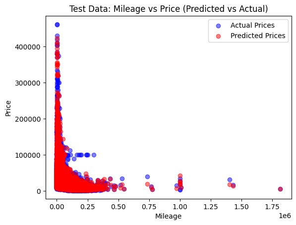

```python
# use the test data for plotting
plt.scatter(X_test_og['Mileage'], y_test_og, label="Actual Prices", alpha=0.5, color="blue")
plt.scatter(X_test_og['Mileage'], yhat, color="red", label="Predicted Prices", alpha=0.5)
plt.xlabel("Mileage")
plt.ylabel("Price")
plt.title("Test Data: Mileage vs Price (Predicted vs Actual)")
plt.legend()
plt.show()
```

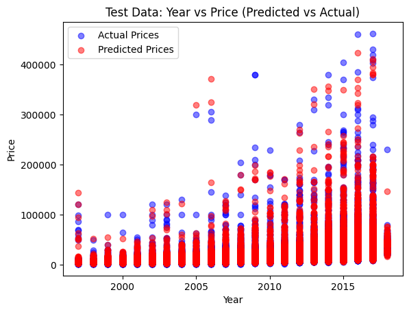

```python
plt.scatter(X_test_og['Year'], y_test_og, label="Actual Prices", alpha=0.5, color="blue")
plt.scatter(X_test_og['Year'], yhat, color="red", label="Predicted Prices", alpha=0.5)
plt.xlabel("Year")
plt.ylabel("Price")
plt.title("Test Data: Year vs Price (Predicted vs Actual)")
plt.legend()
plt.show()
```

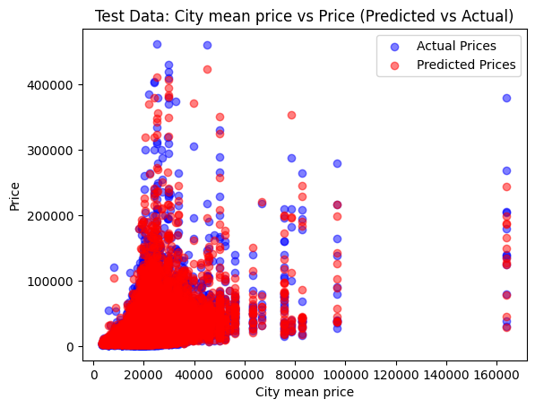

```python
plt.scatter(X_test_og['City_mean_price'], y_test_og, label="Actual Prices", alpha=0.5, color="blue")
plt.scatter(X_test_og['City_mean_price'], yhat, color="red", label="Predicted Prices", alpha=0.5)
plt.xlabel("City mean price")
plt.ylabel("Price")
plt.title("Test Data: City mean price vs Price (Predicted vs Actual)")
plt.legend()
plt.show()
```

```python
mse = mean_squared_error(y_test_og, yhat)
print(f"Mean Squared Error: {mse}")

rmse = np.sqrt(mse)

print(f"Root Mean Squared Error: {rmse}")

print(f"Average price of car: {df_og['Price'].mean()}")
```

```
Mean Squared Error: 15648100.382056758
Root Mean Squared Error: 3955.767988906422
Average price of car: 21463.812309411765
```

```python
r2 = r2_score(y_test_og, yhat)
print(f"R-squared: {r2}")

#the closer to 1 the better, the closer to 0 the worse
```

```
R-squared: 0.9142723873672065
```

## Final Model

```python
test_df = pd.read_csv("used_car_question.csv")
test_df.head()
```

|  | id | Price | Year | Mileage | City | State | Make | Model |
| --- | --- | --- | --- | --- | --- | --- | --- | --- |
| 0 | 850001 | NaN | 2007 | 186177 | Columbus | OH | Honda | Accord |
| 1 | 850002 | NaN | 2015 | 12134 | Plano | TX | Mercedes-Benz | E-ClassE350 |
| 2 | 850003 | NaN | 2016 | 27930 | West Park | FL | Nissan | SentraSL |
| 3 | 850004 | NaN | 2014 | 32349 | Corvallis | OR | Mazda | Mazda3s |
| 4 | 850005 | NaN | 2012 | 53586 | Dartmouth | MA | Nissan | RogueAWD |

```python
#apply the same mappings to the test set that i did in the training
test_df['Make_mean_price'] = test_df['Make'].map(make_mean_price)
test_df['Model_mean_price'] = test_df['Model'].map(model_mean_price)
test_df['City_mean_price'] = test_df['City'].map(city_mean_price)
test_df['State_mean_price'] = test_df['State'].map(state_mean_price)

# drop the original categorical columns
test_df.drop(columns=['Make', 'Model', 'City', 'State', 'id', 'Price'], inplace=True)

final_X_test = test_df

final_X_test.head()
```

|  | Year | Mileage | Make_mean_price | Model_mean_price | City_mean_price | State_mean_price |
| --- | --- | --- | --- | --- | --- | --- |
| 0 | 2007 | 186177 | 16738.418818 | 15572.390682 | 18943.775764 | 18788.332356 |
| 1 | 2015 | 12134 | 31734.189725 | 31277.025077 | 25789.475127 | 23752.616291 |
| 2 | 2016 | 27930 | 16726.072521 | 15251.628722 | 16988.784024 | 20990.653518 |
| 3 | 2014 | 32349 | 15820.482068 | 18138.534704 | 21947.348837 | 22129.264754 |
| 4 | 2012 | 53586 | 16726.072521 | 10496.879227 | 19837.440415 | 21680.836687 |

```python
print(final_X_test.shape)
```

```
(2122, 6)
```

```python
final_yhat = best_model.predict(final_X_test)
```

```python
print(final_yhat.shape)
print(final_yhat)
```

```
(2122,)
[ 5915.73254285 38612.22731758 14131.7006717  ... 26613.85748091
 14977.70205069 19113.00135692]
```

```python
ids = range(850001, 850001 + len(final_yhat))

# Create a DataFrame with the 'id' and 'Price' columns
submission_df = pd.DataFrame({
    'id': ids,
    'Price': final_yhat
})

# Save the DataFrame to a CSV file
submission_df.to_csv('submission.csv', index=False)
```

## Results Discussion

#### Model Performance

- **RMSE of 3955**: This means that, on average, the model’s predictions are off by 3955 dollars from the actual car prices. Considering the average car price in the dataset is around 21,458 dollars, this RMSE indicates that the model captures the overall trends in the data, though there is still a reasonable amount of error in the predictions.
- **R-squared of 0.91**: The model explains about 91% of the variance in car price. This is a strong result, showing that the model fits the data well and can identify the most important relationships between the features and the target variable.

#### Statistical Analysis of the Data

The statistics show a significant spread in the data, with car prices ranging from as low as 1,500 to as high as 499,500. The mileage also varies widely, with cars ranging from low mileage vehicles (e.g., 5 miles) to those with extraordinarily high mileage (up to 2.8 million miles), which could be considered outliers. The `Year` variable shows that most cars are relatively recent, with an average age of 12 years.

I found success from removing outliers in the training data results, however once put into Kaggle the RMSE was significantly worse so I ultimately decided it was best to keep the outliers.

#### Kaggle Results

On Kaggle, my model achieved a **lower RMSE of 2772** on 10% of the test data, which is an improvement over the RMSE obtained in this notebook. This suggests that the test set used on Kaggle may contain simpler or less variable data compared to the dataset in this notebook, potentially leading to a better performance. Since the Kaggle performance is based on a smaller subset, it’s possible that the RMSE will increase when the model is tested on the complete dataset. I hope the RMSE will not exceed the RMSE observed here.

#### Model Analysis and Conclusion

Given the wide variation in the dataset (particularly in car prices and mileages), the model has learned to deal with such complexity. However, further hyperparameter tuning and optimization could lead to improved performance. Additionally, the model’s performance on the full Kaggle test set will provide a clearer indication of its accuracy.